# Lab 8 : CIPRES tutorial

### This is a step by step tutorial for doing a multiple sequence aligment and phylogenetic analysis in CIPRES

Log into [CIPRES](https://www.phylo.org/) and create a new folder

[figure not shown]

Go into the Data folder. Upload your Tree_of_Life_Cores_sequences.fna file

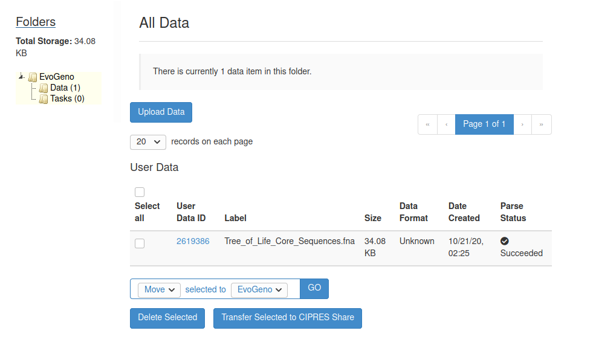

#### Running MAFFT

Click on the Tasks Folder. Create New Task. Select the input file (Tree_of_Life_Cores_sequences.fna). Select the tool (MAFFT). Select the parameter set. Show Advanced Parameters and then Save Parameters.

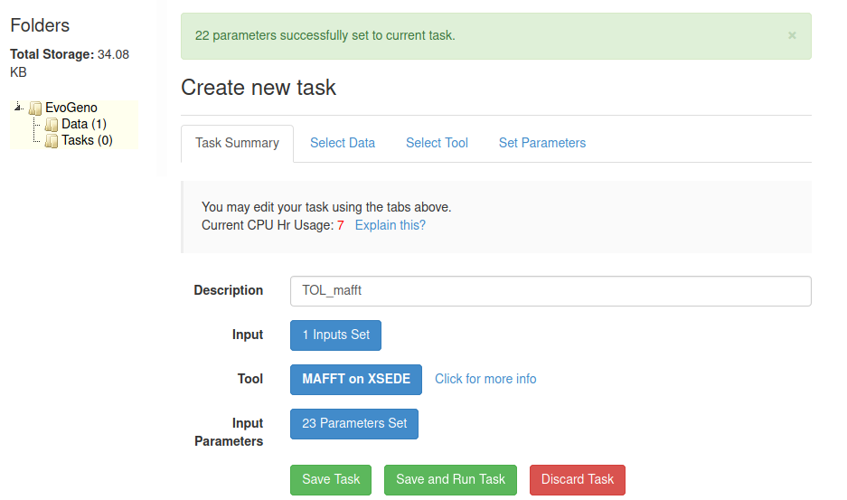

Save and Run Task. You will get an email when the Task (Job) is finished

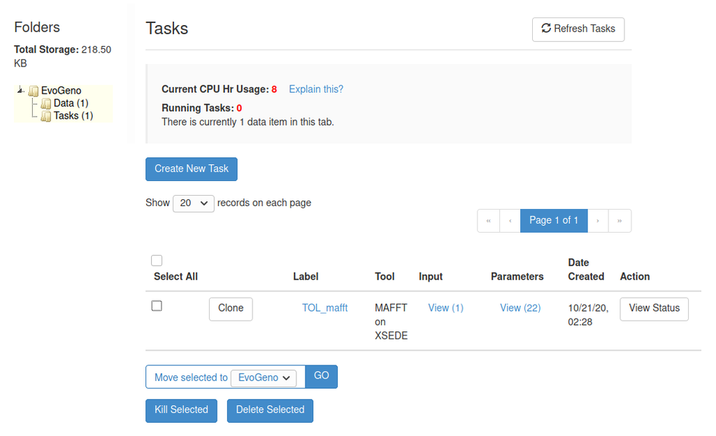

When the task is finished, click on the Label `TOL_mafft`

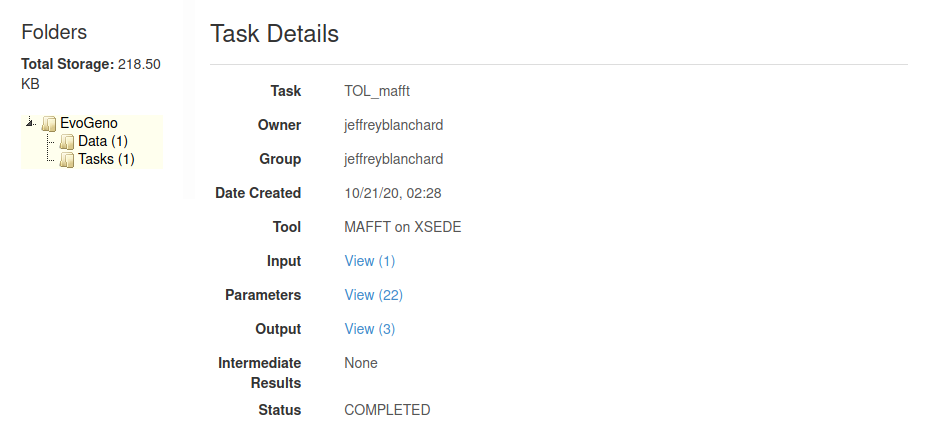

Click on Output `View`

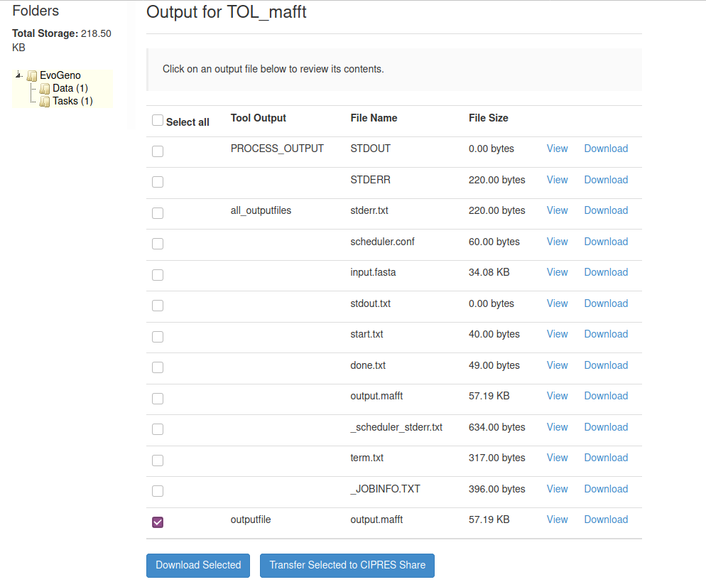

Click on View, Rename and Save to Current Folder.

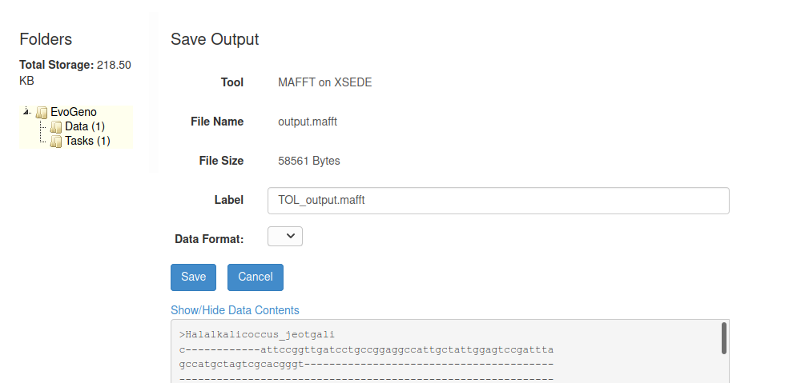

This file will be saved in your data folder.

#### Running FasttreeMP

Create a new task. Use for input the TOL_mafft_ouput file

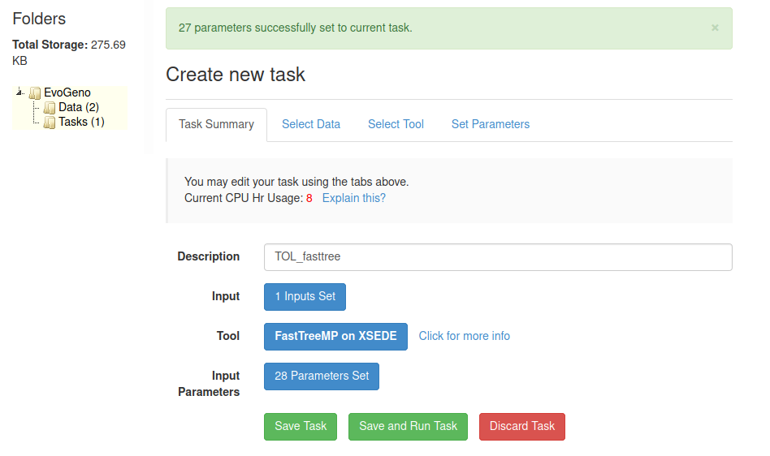

Save and Run Task. When the job is finished as above with the MAFFT results click on the Label `TOL_fastree` and then Output `View` and then fastree_result.tre `View`. Rename and Save to Current Folder

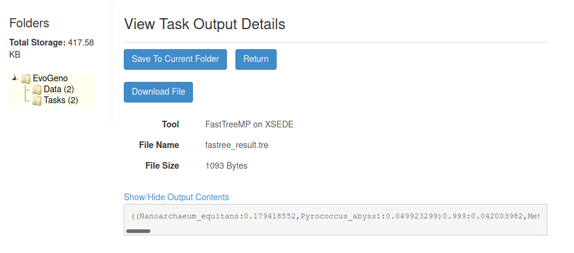

#### Downloading your files to use in MSA and Tree Visualization applications

Go to you Data folder. Click on the link for Data ID link for TOL_output.mafft Save to your local computer in your GitHub directory for the class. You can upload and view the sequence alignmentin several MSA viewers including [Mview](https://www.ebi.ac.uk/Tools/msa/mview/)

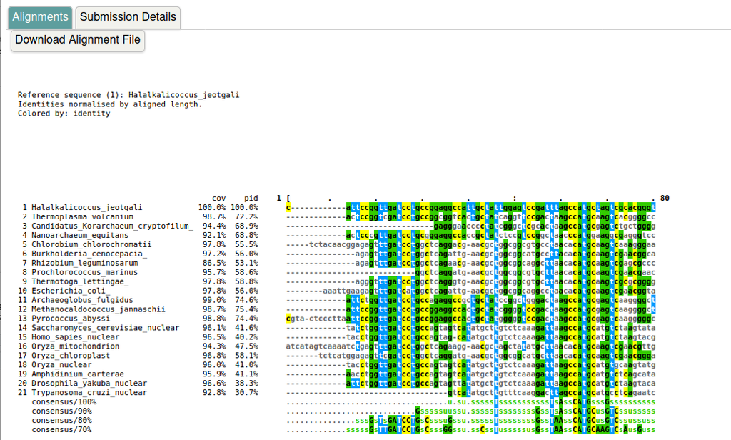

Now download you TOL_fastree_result.tre file. Save to your local computer in your GitHub directory for the class. This is the tree file for using in `ggtree` and other tree visualization programs. This is a newick tree file. There is no need to, but you can open it up on your computer in text editors such as Notepad (Windows) and TextEdit (OSX).